# Progressive guessing is better

This notebook shows that guessing the Hamming weight $h'$ progressively and guessing nonzero-positions+nonzero values is beneficial to just fixing h' and guessing the latter two.

We will proceed on a concrete example we'd like to break: kyber (256,2,25).

Consider $n=512$ dimensional lwe instance with Binomial(2) distribution and exactly $h=25$ nonzero coodinates in $\vec{s}$. We'd like to guess the nonzero coordinates within the last $k=109$ coordinates of $\vec{s}$. If we fail to do so, we'd need to permute the coordinates of $\vec{s}$ and vectors of $\mat(A)$ accordingly (this yields in a BKZ reduction).

Below, I provide the three following figures comparing the progressive vs. single-weight guessing:

```
{0: 256, 1: 27904, 2: 1506816, 3: 53743104, 4: 1424192256, 5: 29908037376, 6: 518405981184, 7: 7627973723136, 8: 97256664969984} {0: 256, 1: 28160, 2: 1534976, 3: 55278080, 4: 1479470336, 5: 31387507712, 6: 549793488896, 7: 8177767212032, 8: 105434432182016}
```

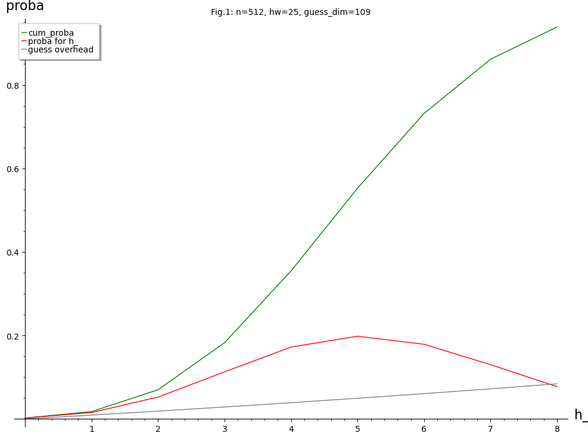

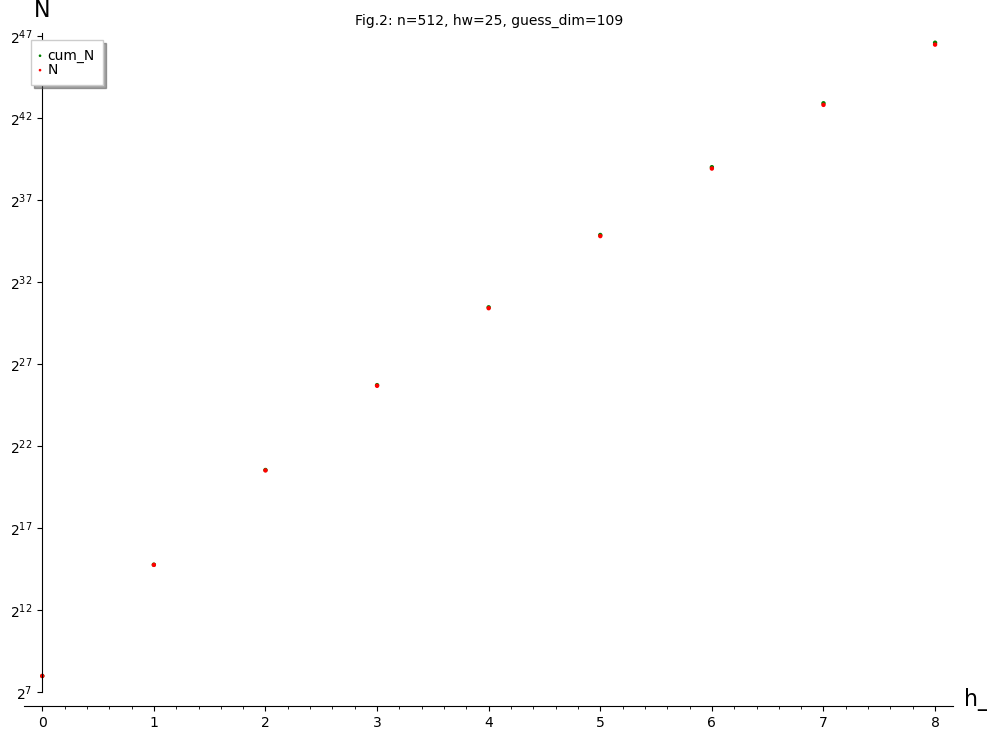

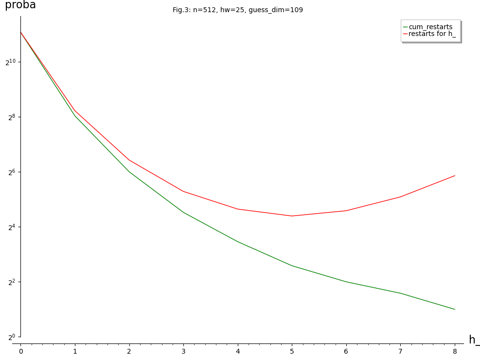

```python
from estimator import *
import estimator
from estimator.lwe_parameters import *

def drop(n, h, k, fail=0, rotations=False):
    """
    Probability that ``k`` randomly sampled components have ``fail`` non-zero components amongst
    them.

    :param n: LWE dimension `n > 0`
    :param h: number of non-zero components
    :param k: number of components to ignore
    :param fail: we tolerate ``fail`` number of non-zero components amongst the `k` ignored
        components
    :param rotations: consider rotations of the basis to exploit ring structure (NTRU only)
    """

    N = n  # population size
    K = n - h  # number of success states in the population
    n = k  # number of draws
    k = n - fail  # number of observed successes
    prob_drop = binomial(K, k) * binomial(N - K, n - k) / binomial(N, n)
    if rotations:
        return 1 - (1 - prob_drop) ** N
    else:
        return prob_drop

def draws_for_confidence(n, k, w, h, confidence):
    p = binomial(n - k, w - h) * binomial(k, h) / binomial(n, w)
    return 1 if p > confidence else ceil(log(1 - confidence) / log(1 - p))


def required_iterations(params, success_probability=0.99):
    N, k, w, h_ = params["n"] * params.get("k_dim", 1), params['k'], params['w'], params['h_']
    return draws_for_confidence(N, k, w, h_, success_probability)

n = 512 #lwe dimension
h = 25 #Hamming weisht of $\vec{s}$
k = 109 #guessing dim
eta = 2 #Binomial eta

cumproba = 0
N = 0
cumN = 0
probas, cumprobas = {}, {}
Ns, cumNs = {}, {}
confidence = 0.99

guess_overheads = {}
req_it_single_weights, req_it_cum_weights = {}, {}

for w in range(9):
    proba = ( binomial(k,w) ) * binomial(n-k,h-w) / binomial(n,h) #the probability of last k coordinates being of hw exactly w
    cumproba += proba.n()
    probas[w] = proba
    cumprobas[w] = cumproba

    curn = binomial(k,w) * 4**( 2*eta ) #the numbber of guesses
    N+=curn
    Ns[w] = curn
    cumNs[w] = N

    guess_overheads[w] = ((N-curn)/curn) #in percentage of curn

    # print(f"w:{w}, pr: {proba.n()}, cumpr:{cumproba}, num={curn}, ")
    req_it_single_weight = required_iterations({'n':n,'k_dim':1, 'k':k, 'w':h, 'h_':w })
    req_it_cum_weight = ceil(log(1 - confidence) / log(1 - cumproba))
    # print(f"req_it_single_weight: {req_it_single_weight}") #how many restarts if we guess only the secrets with w nonzeros
    # print(f"req_it_cum_weight: {req_it_cum_weight}") #same but if we guess UP TO w nonzeros
    req_it_single_weights[w] = req_it_single_weight
    req_it_cum_weights[w] = req_it_cum_weight

    # print( drop(n, h, k, fail=w).n() ) #okay here

# print( float( cumproba ), log(N,2).n() )
print(Ns, cumNs)

plt = list_plot(cumprobas,color="green", legend_label="cum_proba", plotjoined=True) + list_plot(probas,color="red", title=f"Fig.1: n={n}, hw={h}, guess_dim={k}",\
                                                            legend_label="proba for h_", axes_labels=["h_","proba"], plotjoined=True)+\
list_plot(guess_overheads,color="gray", legend_label="guess overhead", plotjoined=True, figsize=10)
plt.show()

plt = list_plot_semilogy(cumNs,color="green", legend_label="cum_N",base=2) + list_plot_semilogy(Ns,color="red", title=f"Fig.2: n={n}, hw={h}, guess_dim={k}",\
                                                            legend_label="N", axes_labels=["h_","N"], base=2, figsize=10)
plt.show()
plt = list_plot_semilogy(req_it_cum_weights,color="green", legend_label="cum_restarts", plotjoined=True, base=2) +\
list_plot_semilogy(req_it_single_weights,color="red", title=f"Fig.3: n={n}, hw={h}, guess_dim={k}",\
legend_label="restarts for h_", axes_labels=["h_","proba"], plotjoined=True, base=2, figsize=10)
plt.show()
```

So, for instance, guessing weights $0,1,2,3$ and $4$ will result in the following differences wrt. guessing only for weight $4$:

- Succ. proba goes from ~0.172 to ~0.355
- We need to make only 3.88% more guesses vs. single-weight approach.
- We lower the number of restarts from 25 to 11 (99% confidence)

```python
print( cumprobas[3], probas[3].n() )
print( guess_overheads[3].n()*100 )
print( req_it_cum_weights[3], req_it_single_weights[4] )
```

```
0.182584447264103 0.112736681185428
2.85613573789858
23 25
```

On the parameter set type_binomial(2, 1) | {'n': 256, 'q': 18839, 'w': 14, 'beta': 40, 'eta_svp': 2, 'm': 187, 'k': 115, 'h_': 3}} I report the following comparison or #iters and the runtimes (all averaged over 5 runs):

NEW vs. OLD:

Runtimes: 166.00132212638854 vs. 195.3151915550232

iterations_used: 22.4 vs. 27.2